# Monocle 3

[Clustering and classifying your cells](https://cole-trapnell-lab.github.io/monocle3/docs/clustering/)

Single-cell experiments are often performed on tissues containing many cell types. Monocle 3 provides a simple set of functions you can use to group your cells according to their gene expression profiles into clusters. Often cells form clusters that correspond to one cell type or a set of highly related cell types. Monocle 3 uses techniques to do this that are widely accepted in single-cell RNA-seq analysis and similar to the approaches used by Seurat, scanpy, and other tools.

In this section, you will learn how to cluster cells using Monocle 3. We will demonstrate the main functions used for clustering with the C. elegans data from Cao & Packer et al. This study described how to do single-cell RNA-seq with combinatorial indexing in a protocol called “sci-RNA-seq”. Cao & Packer et al. used sci-RNA-seq to produce the first single-cell RNA-seq analysis of a whole animal, so there are many cell types represented in the data. You can learn more about the dataset and see how the authors performed the original analysis at the UW Genome Sciences RNA Atlas of the Worm site.

You can load the data into Monocle 3 like this:

```r
library(monocle3)
library(dplyr) # imported for some downstream data manipulation
expression_matrix <- readRDS(url("http://staff.washington.edu/hpliner/data/cao_l2_expression.rds"))
cell_metadata <- readRDS(url("http://staff.washington.edu/hpliner/data/cao_l2_colData.rds"))
gene_annotation <- readRDS(url("http://staff.washington.edu/hpliner/data/cao_l2_rowData.rds"))
cds <- new_cell_data_set(expression_matrix,
                         cell_metadata = cell_metadata,
                         gene_metadata = gene_annotation)
```

# Pre-process the data

Now that the data’s all loaded up, we need to pre-process it. This step is where you tell Monocle 3 how you want to normalize the data, whether to use Principal Components Analysis (the standard for RNA-seq) or Latent Semantic Indexing (common in ATAC-seq), and how to remove any batch effects. We will just use the standard PCA method in this demonstration. When using PCA, you should specify the number of principal components you want Monocle to compute.

```r
cds <- preprocess_cds(cds, num_dim = 100)
```

It’s a good idea to check that you’re using enough PCs to capture most of the variation in gene expression across all the cells in the data set. You can look at the fraction of variation explained by each PC using plot_pc_variance_explained():

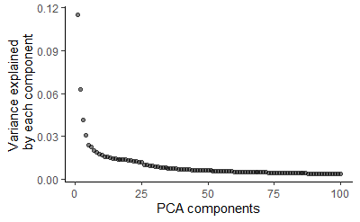

```r
plot_pc_variance_explained(cds)
```

We can see that using more than 100 PCs would capture only a small amount of additional variation, and each additional PC makes downstream steps in Monocle slower.

# Reduce dimensionality and visualize the cells

Now we’re ready to visualize the cells. To do so, you can use either t-SNE, which is very popular in single-cell RNA-seq, or UMAP, which is increasingly common. Monocle 3 uses UMAP by default, as we feel that it is both faster and better suited for clustering and trajectory analysis in RNA-seq. To reduce the dimensionality of the data down into the X, Y plane so we can plot it easily, call reduce_dimension():

```r
cds <- reduce_dimension(cds)
```

```
No preprocess_method specified, using preprocess_method = 'PCA'
```

To plot the data, use Monocle’s main plotting function, plot_cells():

```
No trajectory to plot. Has learn_graph() been called yet?
cluster not found in colData(cds), cells will not be colored
cluster_cells() has not been called yet, can't color cells by cluster
```

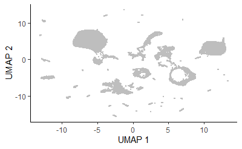

```r
plot_cells(cds)
```

Each point in the plot above represents a different cell in the cell_data_set object cds. As you can see the cells form many groups, some with thousands of cells, some with only a few. Cao & Packer annotated each cell according to type manually by looking at which genes it expresses. We can color the cells in the UMAP plot by the authors’ original annotations using the color_cells_by argument to plot_cells().

```
No trajectory to plot. Has learn_graph() been called yet?
```

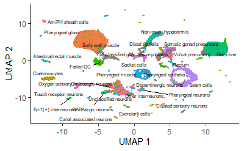

```r
plot_cells(cds, color_cells_by="cao_cell_type")
```

You can see that many of the cell types land very close to one another in the UMAP plot.

Except for a few cases described in a moment, color_cells_by can be the name of any column in colData(cds). Note that when color_cells_by is a categorical variable, labels are added to the plot, with each label positioned roughly in the middle of all the cells that have that label.

You can also color your cells according to how much of a gene or set of genes they express:

```
No trajectory to plot. Has learn_graph() been called yet?
```

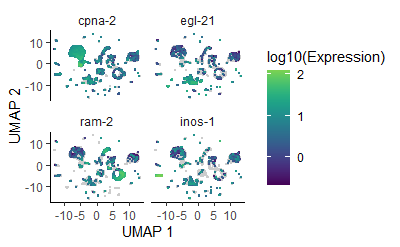

```r
plot_cells(cds, genes=c("cpna-2", "egl-21", "ram-2", "inos-1"))
```

## Faster clustering with UMAP

If you have a relatively large dataset (with >10,000 cells or more), you may want to take advantage of options that can accelerate UMAP. Passing umap.fast_sgd=TRUE to reduce_dimension() will use a fast stochastic gradient descent method inside of UMAP. If your computer has multiple cores, you can use the cores argument to make UMAP multithreaded. However, invoking reduce_dimension() with either of these options will make it produce slighly different output each time you run it. If this is acceptable to you, you could see signifant reductions in the running time of reduction_dimension().

If you want, you can also use t-SNE to visualize your data. First, call reduce_dimension with reduction_method=“tSNE”.

```r
cds <- reduce_dimension(cds, reduction_method="tSNE")
```

```
No preprocess_method specified, using preprocess_method = 'PCA'
```

Then, when you call plot_cells(), pass reduction_method=“tSNE” to it as well:

```
No trajectory to plot. Has learn_graph() been called yet?
```

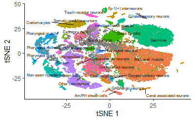

```r
plot_cells(cds, reduction_method="tSNE", color_cells_by="cao_cell_type")
```

You can actually use UMAP and t-SNE on the same cds object - one won’t overwrite the results of the other. But you must specify which one you want in downstream functions like plot_cells.

# Check for and remove batch effects

When performing gene expression analysis, it’s important to check for batch effects, which are systematic differences in the transcriptome of cells measured in different experimental batches. These could be technical in nature, such as those introduced during the single-cell RNA-seq protocol, or biological, such as those that might arise from different litters of mice. How to recognize batch effects and account for them so that they don’t confound your analysis can be a complex issue, but Monocle provides tools for dealing with them.

You should always check for batch effects when you perform dimensionality reduction. You should add a column to the colData that encodes which batch each cell is from. Then you can simply color the cells by batch. Cao & Packer et al included a “plate” annotation in their data, which specifies which sci-RNA-seq plate each cell originated from. Coloring the UMAP by plate reveals:

```
No trajectory to plot. Has learn_graph() been called yet?
```

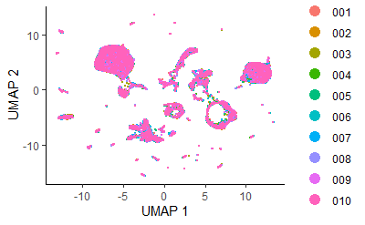

```r
plot_cells(cds, color_cells_by="plate", label_cell_groups=FALSE)
```

Dramatic batch effects are not evident in this data. If the data contained more substantial variation due to plate, we’d expect to see groups of cells that really only come from one plate. Nevertheless, we can try and remove what batch effect is by running the align_cds() function:

```r
cds = align_cds(cds, num_dim = 100, alignment_group = "plate")
```

```
Aligning cells from different batches using Batchelor.
Please remember to cite:
     Haghverdi L, Lun ATL, Morgan MD, Marioni JC (2018). 'Batch effects in single-cell RNA-sequencing data are corrected by matching mutual nearest neighbors.' Nat. Biotechnol., 36(5), 421-427. doi: 10.1038/nbt.4091
```

```r
cds = reduce_dimension(cds)
```

```
No preprocess_method specified, and aligned coordinates have been computed previously. Using preprocess_method = 'Aligned'
```

```
No trajectory to plot. Has learn_graph() been called yet?
```

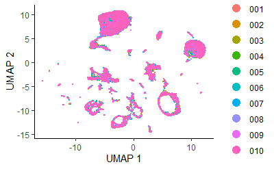

```r
plot_cells(cds, color_cells_by="plate", label_cell_groups=FALSE)
```

When run with the alignment_group argument, align_cds() tries to remove batch effects using mutual nearest neighbor alignment, a technique introduced by John Marioni’s lab. Monocle 3 does so by calling Aaron Lun’s excellent package batchelor. If you use align_cds(), be sure to call get_citations() to see how you should cite the software on which Monocle depends.

# Group cells into clusters

Grouping cells into clusters is an important step in identifying the cell types represented in your data. Monocle uses a technique called community detection to group cells. This approach was introduced by Levine et al as part of the phenoGraph algorithm. You can cluster your cells using the cluster_cells() function, like this:

```
No trajectory to plot. Has learn_graph() been called yet?
The `add` argument of `group_by()` is deprecated as of dplyr 1.0.0.
Please use the `.add` argument instead.
```

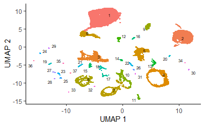

```r
cds = cluster_cells(cds, resolution=1e-5)
plot_cells(cds)
```

Note that now when we call plot_cells() with no arguments, it colors the cells by cluster according to default.

The cluster_cells() also divides the cells into larger, more well separated groups called partitions, using a statistical test from Alex Wolf et al, introduced as part of their PAGA algorithm. You can visualize these partitions like this:

```
No trajectory to plot. Has learn_graph() been called yet?
```

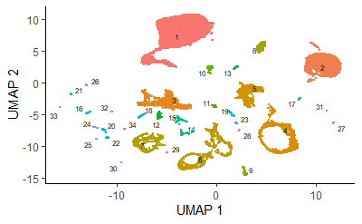

```r
plot_cells(cds, color_cells_by="partition", group_cells_by="partition")
```

Once you run cluster_cells(), the plot_cells() function will label each cluster of cells is labeled separately according to how you want to color the cells. For example, the call below colors the cells according to their cell type annotation, and each cluster is labeled according the most common annotation within it:

```
No trajectory to plot. Has learn_graph() been called yet?
```

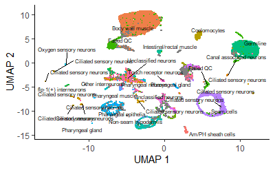

```r
plot_cells(cds, color_cells_by="cao_cell_type")
```

You can choose to label whole partitions instead of clusters by passing group_cells_by=“partition”. You can also plot the top 2 labels per cluster by passing labels_per_group=2 to plot_cells(). Finally, you can disable this labeling policy, making plot_cells() behave like it did before we called cluster_cells(), like this:

```
No trajectory to plot. Has learn_graph() been called yet?
```

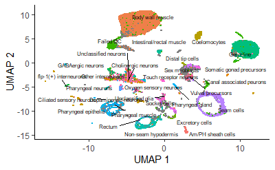

```r
plot_cells(cds, color_cells_by="cao_cell_type", label_groups_by_cluster=FALSE)
```

# Find marker genes expressed by each cluster

Once cells have been clustered, we can ask what genes makes them different from one another. To do that, start by calling the top_markers() function:

```r
marker_test_res <- top_markers(cds, group_cells_by="partition",
                               reference_cells=1000, cores=8)
```

```
mc.cores > 1 is not supported on Windows due to limitation of mc*apply() functions.
  mc.core is set to 1.
```

[output not shown]

[output cut: 20218 more lines]

[output not shown]

```
mc.cores > 1 is not supported on Windows due to limitation of mc*apply() functions.
  mc.core is set to 1.
```

[output not shown]

[output cut: 797 more lines]

[output not shown]

The data frame marker_test_res contains a number of metrics for how specifically expressed each gene is in each partition. We could group the cells according to cluster, partition, or any categorical variable in colData(cds). You can rank the table according to one or more of the specificity metrics and take the top gene for each cluster. For example, pseudo_R2 is one such measure. We can rank markers according to pseudo_R2 like this:

```r
top_specific_markers <- marker_test_res %>%
                            filter(fraction_expressing >= 0.10) %>%
                            group_by(cell_group) %>%
                            top_n(1, pseudo_R2)
top_specific_marker_ids <- unique(top_specific_markers %>% pull(gene_id))
```

Now, we can plot the expression and fraction of cells that express each marker in each group with the plot_genes_by_group function:

```
the condition has length > 1 and only the first element will be used
```

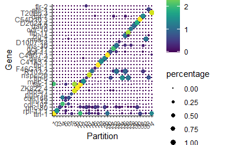

```r
plot_genes_by_group(cds,
                    top_specific_marker_ids,
                    group_cells_by="partition",
                    ordering_type="maximal_on_diag",
                    max.size=3)
```

It’s often informative to look at more than one marker, which you can do just by changing the first argument to top_n():

```
the condition has length > 1 and only the first element will be used
```

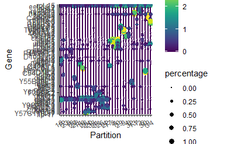

```r
top_specific_markers <- marker_test_res %>%
                            filter(fraction_expressing >= 0.10) %>%
                            group_by(cell_group) %>%
                            top_n(3, pseudo_R2)
top_specific_marker_ids <- unique(top_specific_markers %>% pull(gene_id))
plot_genes_by_group(cds,
                    top_specific_marker_ids,
                    group_cells_by="partition",
                    ordering_type="cluster_row_col",
                    max.size=3)
```

There are many ways to compare and contrast clusters (and other groupings) of cells. We will explore them in great detail in the differential expression analysis section a bit later.

# Annotate your cells according to type

Identifying the type of each cell in your dataset is critical for many downstream analyses. There are several ways of doing this. One commonly used approach is to first cluster the cells and then assign a cell type to each cluster based on its gene expression profile. We’ve already seen how to use top_markers(). Reviewing literature associated with a marker gene often give strong indications of the identity of clusters that express it. In Cao & Packer >et al, the authors consulted literature and gene expression databases for markers restricted to each cluster in order to assign the identities contained in colData(cds)$cao_cell_type.

To assign cell types based on clustering, we begin by creating a new column in colData(cds) and initialize it with the values of partitions(cds) (can also use clusters(cds) depending on your dataset):

```r
colData(cds)$assigned_cell_type <- as.character(partitions(cds))
```

Now, we can use the dplyrpackage’s recode() function to remap each cluster to a different cell type:

```r
colData(cds)$assigned_cell_type = dplyr::recode(colData(cds)$assigned_cell_type,
                                                "1"="Germline",
                                                "2"="Body wall muscle",
                                                "3"="Unclassified neurons",
                                                "4"="Vulval precursors",
                                                "5"="Failed QC",
                                                "6"="Seam cells",
                                                "7"="Pharyngeal epithelia",
                                                "8"="Coelomocytes",
                                                "9"="Am/PH sheath cells",
                                                "10"="Failed QC",
                                                "11"="Touch receptor neurons",
                                                "12"="Intestinal/rectal muscle",
                                                "13"="Pharyngeal neurons",
                                                "14"="NA",
                                                "15"="flp-1(+) interneurons",
                                                "16"="Canal associated neurons",
                                                "17"="Ciliated sensory neurons",
                                                "18"="Other interneurons",
                                                "19"="Pharyngeal gland",
                                                "20"="Failed QC",
                                                "21"="Ciliated sensory neurons",
                                                "22"="Oxygen sensory neurons",
                                                "23"="Ciliated sensory neurons",
                                                "24"="Ciliated sensory neurons",
                                                "25"="Ciliated sensory neurons",
                                                "26"="Ciliated sensory neurons",
                                                "27"="Oxygen sensory neurons",
                                                "28"="Ciliated sensory neurons",
                                                "29"="Unclassified neurons",
                                                "30"="Socket cells",
                                                "31"="Failed QC",
                                                "32"="Pharyngeal gland",
                                                "33"="Ciliated sensory neurons",
                                                "34"="Ciliated sensory neurons",
                                                "35"="Ciliated sensory neurons",
                                                "36"="Failed QC",
                                                "37"="Ciliated sensory neurons",
                                                "38"="Pharyngeal muscle")
```

Let’s see how the new annotations look:

```
No trajectory to plot. Has learn_graph() been called yet?
```

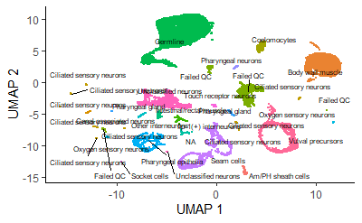

```r
plot_cells(cds, group_cells_by="partition", color_cells_by="assigned_cell_type")
```

Partition 7 has some substructure, and it’s not obvious just from looking at the output of top_markers() what cell type or types it corresponds to. So we can isolate it with the choose_cells() function for further analysis:

```r
cds_subset <- choose_cells(cds)
```

Now we have a smaller cell_data_set object that contains just the cells from the partition we’d like to drill into. We can use graph_test() to identify genes that are differentially expressed in different subsets of cells from this partition:

```r
pr_graph_test_res <- graph_test(cds_subset, neighbor_graph="knn", cores=8)
```

```
mc.cores > 1 is not supported on Windows due to limitation of mc*apply() functions.
  mc.core is set to 1.
```

[output not shown]

[output cut: 20218 more lines]

[output not shown]

```r
pr_deg_ids <- row.names(subset(pr_graph_test_res, morans_I > 0.01 & q_value < 0.05))
```

We will learn more about graph_test() in the differential expression analysis section later. We can take all the genes that vary across this set of cells and group those that have similar patterns of expression into modules:

```r
gene_module_df <- find_gene_modules(cds_subset[pr_deg_ids,], resolution=1e-3)
```

Plotting these modules’ aggregate expression values reveals which cells express which modues.

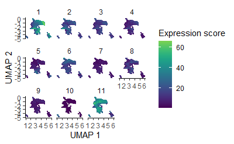

```r
plot_cells(cds_subset, genes=gene_module_df,
           show_trajectory_graph=FALSE,
           label_cell_groups=FALSE)
```

You can explore the genes in each module or conduct gene ontology enrichment analysis on them to glean insights about which cell types are present. Suppose after doing this we have a good idea of what the cell types in the partition are. Let’s recluster the cells at finer resolution and then see how they overlap with the clusters in the partition:

```
No trajectory to plot. Has learn_graph() been called yet?
```

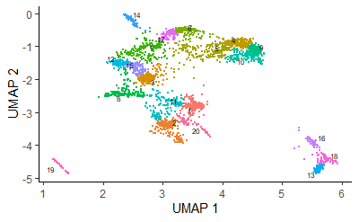

```r
cds_subset = cluster_cells(cds_subset, resolution=1e-2)
plot_cells(cds_subset, color_cells_by="cluster")
```

Based on how the patterns line up, we’ll make the following assignments:

```
No trajectory to plot. Has learn_graph() been called yet?
```

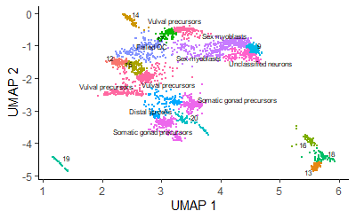

```r
colData(cds_subset)$assigned_cell_type <- as.character(clusters(cds_subset)[colnames(cds_subset)])
colData(cds_subset)$assigned_cell_type <- dplyr::recode(colData(cds_subset)$assigned_cell_type,
                                                        "1"="Somatic gonad precursors",
                                                        "2"="Somatic gonad precursors",
                                                        "3"="Vulval precursors",
                                                        "4"="Sex myoblasts",
                                                        "5"="Sex myoblasts",
                                                        "6"="Vulval precursors",
                                                        "7"="Failed QC",
                                                        "8"="Vulval precursors",
                                                        "10"="Unclassified neurons",
                                                        "11"="Distal tip cells")
plot_cells(cds_subset, group_cells_by="cluster", color_cells_by="assigned_cell_type")
```

Now we can transfer the annotations from the cds_subset object back to the full dataset. We’ll also filter out low-quality cells at this stage

```
No trajectory to plot. Has learn_graph() been called yet?
```

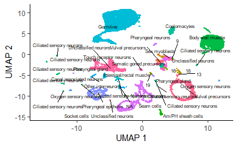

```r
colData(cds)[colnames(cds_subset),]$assigned_cell_type <- colData(cds_subset)$assigned_cell_type
cds <- cds[,colData(cds)$assigned_cell_type != "Failed QC" | is.na(colData(cds)$assigned_cell_type )]
plot_cells(cds, group_cells_by="partition",
           color_cells_by="assigned_cell_type",
           labels_per_group=5)
```

# Automated annotation with Garnett

The above process for manually annotating cells by type can be laborious, and must be re-done if the underlying cluster changes. We recently developed Garnett, a software toolkit for automatically annotating cells. Garnett classifies cells based on marker genes. If you’ve gone through the trouble of annotated your cells manually, Monocle can generate a file of marker genes that can be used with Garnett. This will help you annotate other datasets in the future or reannotate this one if you refine your analysis and update your clustering in the future.

To generate a Garnett file, first find the top markers that each annotated cell type expresses:

```r
assigned_type_marker_test_res <- top_markers(cds,
                                             group_cells_by="assigned_cell_type",
                                             reference_cells=1000,
                                             cores=8)
```

```
mc.cores > 1 is not supported on Windows due to limitation of mc*apply() functions.
  mc.core is set to 1.
```

[output not shown]

[output cut: 20218 more lines]

[output not shown]

```
mc.cores > 1 is not supported on Windows due to limitation of mc*apply() functions.
  mc.core is set to 1.
```

Next, filter these markers according to how stringent you want to be:

```r
# Require that markers have at least JS specificty score > 0.5 and
# be significant in the logistic test for identifying their cell type:
garnett_markers <- assigned_type_marker_test_res %>%
                        filter(marker_test_q_value < 0.01 & specificity >= 0.5) %>%
                        group_by(cell_group) %>%
                        top_n(5, marker_score)
# Exclude genes that are good markers for more than one cell type:
garnett_markers <- garnett_markers %>%
                        group_by(gene_short_name) %>%
                        filter(n() == 1)
```

Then call generate_garnett_marker_file:

```r
generate_garnett_marker_file(garnett_markers, file="./marker_file.txt")
```

```
Group name contained an illegal character for a Garnett  marker file.  Cell type flp-1(+) interneurons  will be substituted for  Cell type flp-1.+. interneurons .Garnett marker file written to ./marker_file.txt
```

The marker files produced by generate_garnett_marker_file() are just a starting point for classifying your cells with Garnett. You may want to edit this file to add or remove markers based on literature or other information. You also should consider defining subtypes of cells, which can greatly increase the usefulness and accuracy of Garnett. For example, the L2 data contains many different types of neurons. Making a “Neuron” cell type in the file above and then using the subtype of keyword to organize the various subtypes of neurons will make Garnett more able to recognize them and distinguish them from non-neuronal cell types. When two or more of your cell types share most of their top markers in plot_genes_by_group(), consider defining a broader cell type definition of which they are both subtypes. You might also want to define markers for the various subtypes of neurons by subsetting the cds object above and running top_markers() just on them. See the Garnett documentation for more on how you can enrich your marker files.

When you’re ready run Garnett, load the package:

## Garnett for Monocle 3

Garnett was originally written to work with Monocle 2. We have created a branch of Garnett that works with Monocle 3, which will eventually replace the main branch. In the meantime, you must install and load the Monocle 3 branch of Garnett!

```r
## Install the monocle3 branch of garnett
BiocManager::install(c("org.Mm.eg.db", "org.Hs.eg.db"))
a
```

[output not shown]

```
  There is a binary version available but the source version is later:
```

|  | binary | source | needs_compilation |
| --- | --- | --- | --- |
| rtracklayer | 1.49.5 | 1.50.0 | TRUE |

```
  Binaries will be installed
```

[output not shown]

```r
devtools::install_github("cole-trapnell-lab/garnett", ref="monocle3")
```

```r
library(garnett)
# install gene database for worm
BiocManager::install("org.Ce.eg.db")
a
```

[output not shown]

```
  There is a binary version available but the source version is later:
```

|  | binary | source | needs_compilation |
| --- | --- | --- | --- |
| rtracklayer | 1.49.5 | 1.50.0 | TRUE |

```
  Binaries will be installed
```

[output not shown]

Now train a Garnett classifier based on your marker file like this:

```r
colData(cds)$garnett_cluster <- clusters(cds)
worm_classifier <- train_cell_classifier(cds = cds,
                                         marker_file = "./marker_file.txt",
                                         db=org.Ce.eg.db::org.Ce.eg.db,
                                         cds_gene_id_type = "ENSEMBL",
                                         num_unknown = 50,
                                         marker_file_gene_id_type = "SYMBOL",
                                         cores=8)
```

```
There are 23 cell type definitions
7 genes could not be converted from SYMBOL to ENSEMBL These genes are listed below: The following genes from the cell type definition file are not present inthe cell dataset.  Please check these genes for errors. Cell typedetermination will continue, ignoring these genes.
H05L03.3
ZC412.4
F46G11.1
C41A3.1
prg-2
Y66D12A.14
ZC116.3
```

```
training_sample
                      Cell type 14                       Cell type 17
                               250                                277
                      Cell type 18                       Cell type 19
                                36                                 20
                      Cell type 20       Cell type Am/PH sheath cells
                               207                                458
        Cell type Body wall muscle Cell type Canal associated neurons
                               500                                300
Cell type Ciliated sensory neurons             Cell type Coelomocytes
                               158                                500
   Cell type flp-1.+. interneurons                 Cell type Germline
                               108                                500
Cell type Intestinal/rectal muscle       Cell type Other interneurons
                               234                                244
  Cell type Oxygen sensory neurons     Cell type Pharyngeal epithelia
                               412                                500
        Cell type Pharyngeal gland       Cell type Pharyngeal neurons
                                79                                231
              Cell type Seam cells             Cell type Socket cells
                               500                                 50
  Cell type Touch receptor neurons     Cell type Unclassified neurons
                               500                                500
       Cell type Vulval precursors                            Unknown
                               500                                 50
```

```
Model training finished.
```

Now that we’ve trained a classifier worm_classifier, we can use it to annotate the L2 cells according to type:

```r
cds <- classify_cells(cds, worm_classifier,
                      db = org.Ce.eg.db::org.Ce.eg.db,
                      cluster_extend = TRUE,
                      cds_gene_id_type = "ENSEMBL")
```

Here’s how Garnett annotated the cells:

```
No trajectory to plot. Has learn_graph() been called yet?
```

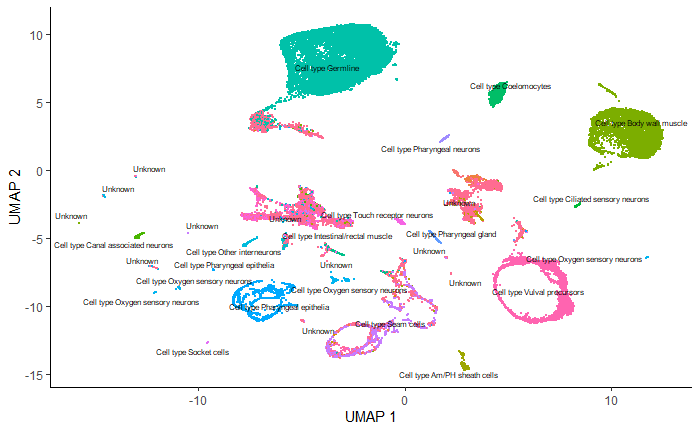

```r
plot_cells(cds,
           group_cells_by="partition",
           color_cells_by="cluster_ext_type")
```

Garnett classifiers can be applied to datasets other than the one they were trained on. We strongly encourage you to share your Garnett files and include them with your papers so that others can use them.

As part of writing a paper about Garnett, we trained a Garnett model to classify C. elegans cells based on the L2 data. You can classify cells with it by first downloading and then passing it to the classify_cells() function:

```r
ceWhole <- readRDS(url("https://cole-trapnell-lab.github.io/garnett/classifiers/ceWhole_20191017.RDS"))
```